# Part II - PISA2012 Student Scores in Maths, Science, Reading and Other Features Correlating To Them

## Dataset Overview

The dataset consists of more than 400,000 entries and over 600 features of interest. I chose 27 of these features and focused on plausible values 1 for each subject: science, mathematics and reading. Focusing on the plausible values as student performance indicators, I cross examined them with gender of students, age they started learning, and wealth tendency.

## Scores Distribution

The distribution of scores was normally distributed with no significant skewness. This means that the mean and median of the scores are equal, with averages of scores at: Maths 485.93, Science 484.69, Reading 479.67

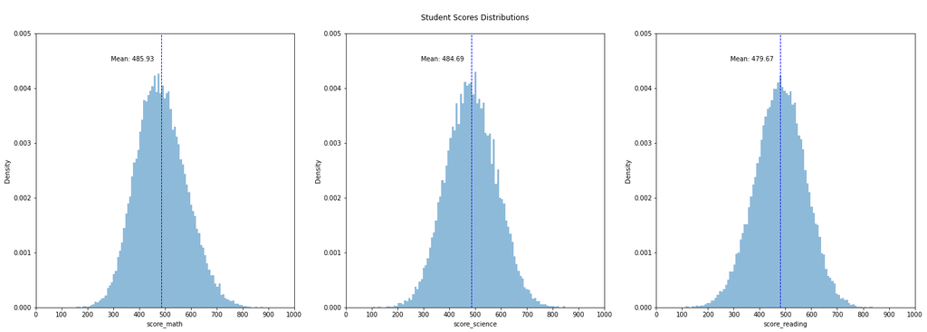

## Student Gender vs Scores

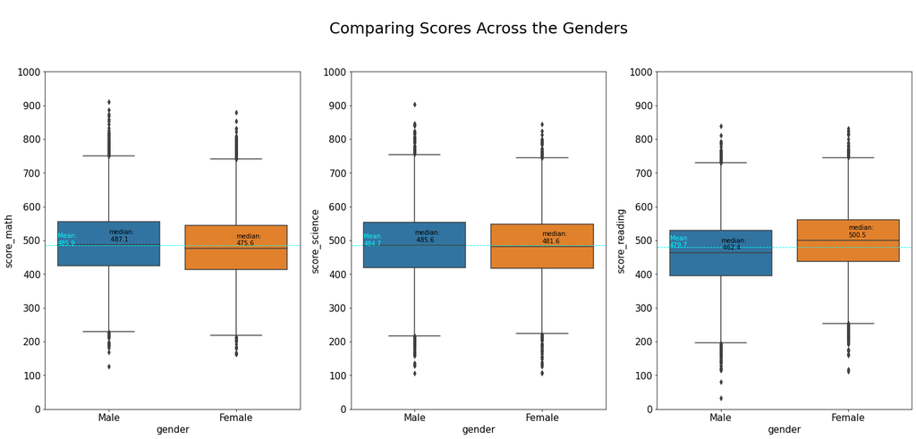

## Student Age Started Learning vs Scores

The most prominent effect on scores was the age the student atarted learning. In this feature, there was a clear inversely proportional relationship with the scores: the later the student begins learning in their lifetime, the lower the scores tend to be.

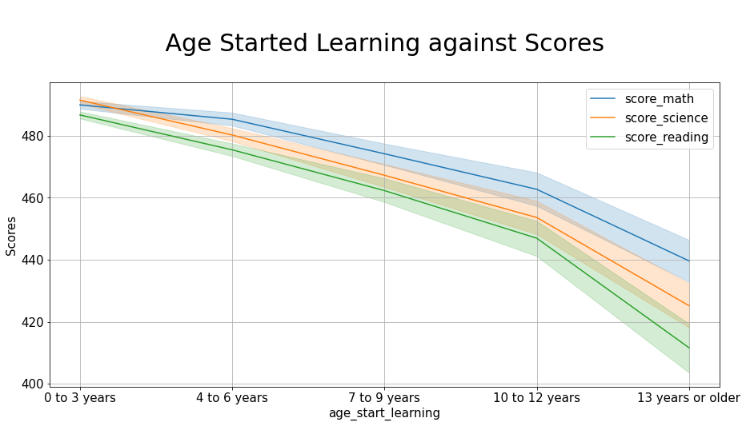

## Student Age Started Learning vs Wealth

Now that we have seen a clear relation between age and score, I wanted to see what other features could relate to age start learning factor. In wealth tendency feature, there is a visible decline in wealth tendency with students who started at a later age of their lifetime. This concludes that students who begin learning at an earlier stage of their lifetime have better wealth (~ 0) tendency than those who started at a later stage (< 0).

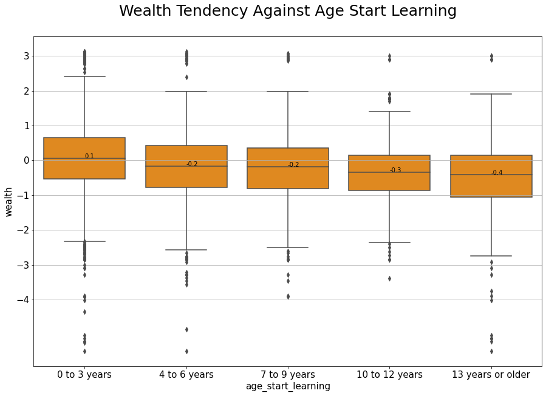